# Applied Data Science Capstone: Week 5

## Segmenting Prospective Neighborhoods to Expand a Coffee Shop Chain

# 1. Introduction

In this project, Foursquare geospatial and venue data will be used to determine which area(s) is best suited to expand a Coffee Shop chain, Kopi Kompleks, around Surabaya, East Java, Indonesia. I would like to say my most profound gratitude to:

1. **[Muhammad Fathin Moerdiwanto](https://www.linkedin.com/in/fathinmoerd/)**, for providing me enough information on the franchise.
2. **[Waode Nurul Jasmin A. Budiman](https://www.linkedin.com/in/waode-nurul-jasmin-azzahra-budiman-628a3378/)**, for helping me obtain Surabaya's map of administration borders in `.shp` format. Check out her [flickr](https://www.flickr.com/photos/99829115@N03/)!
3. **[Taqy Satriaji Santoso](https://www.instagram.com/taqysatriaji/)**, my best friend since high school, for helping me extract `.shp` into `.geojson` with EPSG:4326 format. Check out his [art page](https://www.instagram.com/fro.l.i.c/)!

For without their help, this project wouldn't be completed as it is.

## 1.1. Business Problem Formulation

The franchise in question, [Kopi Kompleks](https://www.instagram.com/kopikompleks/?hl=en), has already opened 4 branches across Surabaya, and is looking to open their fifth one. Since there are already a lot of coffee shop chain in the city, it could potentially be unbeneficial for the franchise to expand into the wrong neighborhood.

This report will help the franchise to determine which area is most prospective, and which area is the least. This report will also be presented to the stakeholders and higher-ups of the franchise, with hopes to aid in their decision-making process.

I will try to:

1. Detect **locations that are not already crowded with cafes**.
2. Detect **areas with no cafe/coffee shops in vicinity**, with hopes of us being the pioneering venue in said area.
3. Detect **areas with high population density**.

## 1.2. Data

The franchise has already opened four branches, in the following areas:

1. Kopi Kompleks, Jl. Slamet No.16A, Ketabang, Kec. Genteng, Kota SBY, Jawa Timur 60272
2. Satu Rasa Kopi by Kopi Kompleks, Jl. Karimata No.1, Ngagel, Kec. Wonokromo, Kota SBY, Jawa Timur 60246
3. Kopilaborasi by Kopi Kompleks, Jl. Raya Pd. Rosan No.19, Babatan, Kec. Wiyung, Kota SBY, Jawa Timur 60227
4. Kopi Kompleks at PanaHouse, Jl. Gayung Kebonsari No.61 - 65, Ketintang, Kec. Gayungan, Kota SBY, Jawa Timur 60231

Based on definition of our problem, factors that will influence our decision are:

- The number of existing coffee shops in the neighborhoods.
- Population density in each of the neighborhoods.

Following data sources will be needed to extract/generate the required information:

- Number of cafe/coffee shops and their location in every neighborhood will be obtained using **Foursquare API**.
- Population density of each and every neighborhood in Surabaya, obtained through [Surabaya's Central of Statistics](https://surabayakota.bps.go.id/subject/12/kependudukan.html#subjekViewTab4)
- Longitude and latitude values of each neighborhood in Surabaya, in .shp file format, obtained through [this ArcGIS online item](https://www.arcgis.com/home/item.html?id=f9a601e6d89a43d9b0abf265a0000785).

I exported the .shp file format through [mapshaper](https://mapshaper.org/) into two formats:

1. A cleaner, more understandable .csv file format
2. A .geojson format with an output coordinate system of **EPSG:4326**

Foursquare data will first be segmented into several clusters, before eventually eliminating clusters that are nearest and/or belongs to the existing four branches of the franchise. This way, we can get unbiased representation of each neighborhoods' preferences, and ultimately determine which areas are the most prospective to open the next branch.

```python
from bs4 import BeautifulSoup
import numpy as np # library to handle data in a vectorized manner
import re # regex library

import pandas as pd # library for data analsysis
pd.set_option('display.max_columns', None)
pd.set_option('display.max_rows', None)

import json # library to handle JSON files
import folium # map rendering library
from geopy.geocoders import Nominatim # convert an address into latitude and longitude values

import requests # library to handle requests
from pandas.io.json import json_normalize # tranform JSON file into a pandas dataframe

# Matplotlib and associated plotting modules
import matplotlib.cm as cm
import matplotlib.colors as colors
from sklearn.cluster import KMeans

print("Libraries imported!")
```

```
Libraries imported!
```

## 1.2.1. Surabaya Geospatial Data

This section covers obtaining and cleaning the latitude and longitude values of each neighborhoods in Surabaya.

```python
df = pd.read_csv("Administrasi_Kelurahan_Surabaya.csv")
df.head()
```

|  | OBJECTID | Id | DESA | KECAMATAN | KABKOT | PROPINSI | X | Y | Z | FillTransp | OutlineTra | SHAPE_Leng | SHAPE_Area |
| --- | --- | --- | --- | --- | --- | --- | --- | --- | --- | --- | --- | --- | --- |
| 0 | 1 | 0 | WARUGUNUNG | KARANG PILANG | SURABAYA | NaN | 112.673585 | -7.342167 | 1 | 49.803922 | 0 | 9913.141714 | 3902169.5 |
| 1 | 2 | 0 | KARANG PILANG | KARANG PILANG | SURABAYA | NaN | 112.689647 | -7.339349 | 1 | 49.803922 | 0 | 6840.293677 | 2164425.5 |
| 2 | 3 | 0 | KEBRAON | KARANG PILANG | SURABAYA | NaN | 112.700501 | -7.330315 | 1 | 49.803922 | 0 | 7984.106871 | 2073235.0 |
| 3 | 4 | 0 | KEDURUS | KARANG PILANG | SURABAYA | NaN | 112.705912 | -7.320099 | 1 | 49.803922 | 0 | 5973.233996 | 1752535.5 |
| 4 | 5 | 0 | PAGESANGAN | JAMBANGAN | SURABAYA | NaN | 112.712619 | -7.334844 | 1 | 49.803922 | 0 | 5102.418403 | 1121491.5 |

We can see that the original .csv file has some unnecessary columns. These columns are:

- **OBJECTID** -- Dropped because it's a duplicate of index.
- **Id** -- Dropped because it's filled with unrepresentative zeroes.
- **KABKOT** -- Dropped because all of them are `SURABAYA`, which is obvious since we're working with Surabaya dataset.
- **PROPINSI** -- Dropped because irrelevant and filled with `NaN` values.
- **Z** -- Dropped because it's filled with unrepresentative ones.
- **FillTransp** -- Dropped because this column is only representative when opened with ArcGIS Desktop.
- **OutlineTra** -- Dropped because this column is only representative when opened with ArcGIS Desktop.
- **SHAPE_Leng** -- Dropped because this column is only representative when opened with ArcGIS Desktop.
- **SHAPE_Area** -- Dropped because this column is only representative when opened with ArcGIS Desktop.

We can drop these said columns to achieve a clearer, more concise dataframe object.

```python
df.drop(['OBJECTID', 'Id', 'KABKOT', 'PROPINSI', 'Z', 'FillTransp', 'OutlineTra', 'SHAPE_Leng', 'SHAPE_Area'], axis=1, inplace=True)

df = df.rename(columns={"DESA": "KELURAHAN", "X": "Longitude", "Y": "Latitude"}) # Rename the rest of the columns for clarity
```

```python
df.head()
```

|  | KELURAHAN | KECAMATAN | Longitude | Latitude |
| --- | --- | --- | --- | --- |
| 0 | WARUGUNUNG | KARANG PILANG | 112.673585 | -7.342167 |
| 1 | KARANG PILANG | KARANG PILANG | 112.689647 | -7.339349 |
| 2 | KEBRAON | KARANG PILANG | 112.700501 | -7.330315 |
| 3 | KEDURUS | KARANG PILANG | 112.705912 | -7.320099 |
| 4 | PAGESANGAN | JAMBANGAN | 112.712619 | -7.334844 |

### Create a map of Surabaya with neighborhoods superimposed on top.

A quick Google search revealed that Surabaya lies on the respective latitude and longitude values: -7.250445, 112.768845. We double-assign these values before mapping the map with folium.

```python
latitude, longitude = -7.265, 112.7107 # Altered slightly to better centerize the map display

# create map of Toronto using latitude and longitude values
map_sby = folium.Map(location=[latitude, longitude], zoom_start=12)

# add markers to map
for lat, lng, kec, kel in zip(df['Latitude'], df['Longitude'], df['KECAMATAN'], df['KELURAHAN']):
    label = '{}, {}'.format(kel, kec)
    label = folium.Popup(label, parse_html=True)
    folium.CircleMarker(
        [lat, lng],
        radius=5,
        popup=label,
        color='blue',
        fill=True,
        fill_color='#3186cc',
        fill_opacity=0.7,
        parse_html=False).add_to(map_sby)

map_sby
```

Make this Notebook Trusted to load map: File -> Trust Notebook

[interactive chart not shown]

We now have a set of datapoints representing each neighborhood (*kelurahan*) in Surabaya.

## 1.2.2. Venue Data from Foursquare API

This section covers the cleaning and transforming data obtained from the GET request to Foursquare API.

### Define Foursquare Credentials and Version

Note that when I share this notebook, I would have to redact the credentials. I hope this is understandable :)

```python
CLIENT_ID = '■■■■■■■■■■■■■■■■■■■■■■■■■' # Foursquare ID
CLIENT_SECRET = '■■■■■■■■■■■■■■■■■■■■■■■■■' # Foursquare Secret
VERSION = '20180605' # Foursquare API version

print('Using the following credentials:')
print('CLIENT_ID: ' + CLIENT_ID)
print('CLIENT_SECRET:' + CLIENT_SECRET)
```

```
Using the following credentials:
CLIENT_ID: ■■■■■■■■■■■■■■■■■■■■■■■■■
CLIENT_SECRET:■■■■■■■■■■■■■■■■■■■■■■■■■
```

### Define a few functions to use for exploratory analysis

```python
# function that extracts the category of the venue
def get_category_type(row):
    try:
        categories_list = row['categories']
    except:
        categories_list = row['venue.categories']

    if len(categories_list) == 0:
        return None
    else:
        return categories_list[0]['name']

# function that returns venues in an area, given latitude and longitude
def getNearbyVenues(names, latitudes, longitudes, radius=500):
    venues_list=[]
    for name, lat, lng in zip(names, latitudes, longitudes):
        # print(name) # uncomment to debug. I commented it to preserve memory

        # create the API request URL
        url = 'https://api.foursquare.com/v2/venues/explore?&client_id={}&client_secret={}&v={}&ll={},{}&radius={}&limit={}'.format(
            CLIENT_ID,
            CLIENT_SECRET,
            VERSION,
            lat,
            lng,
            radius,
            100) # Get the results of the top 100 venues.

        # make the GET request
        # print(requests.get(url).json()["response"]) # uncomment to debug in case we've overused our GET request limit.
        results = requests.get(url).json()["response"]['groups'][0]['items']

        # return only relevant information for each nearby venue
        venues_list.append([(
            name,
            lat,
            lng,
            v['venue']['name'],
            v['venue']['location']['lat'],
            v['venue']['location']['lng'],
            v['venue']['categories'][0]['name']) for v in results])

    nearby_venues = pd.DataFrame([item for venue_list in venues_list for item in venue_list])
    nearby_venues.columns = ['Neighborhood',
                  'Neighborhood Latitude',
                  'Neighborhood Longitude',
                  'Venue',
                  'Venue Latitude',
                  'Venue Longitude',
                  'Venue Category']

    return(nearby_venues)
```

```python
#sby_venues = getNearbyVenues(names=df['KELURAHAN'], latitudes=df['Latitude'], longitudes=df['Longitude'])
#Uncomment to make function call the Foursquare API.
```

### Display the end dataframe

The dataframe consists of venue properties along with its appropriate neighborhood.

```python
#sby_venues.to_csv("processed.csv") # Write csv file as a checkpoint in case we overuse the API call quota
sby_venues = pd.read_csv("processed.csv")
sby_venues.drop('Unnamed: 0', inplace=True,axis=1)
sby_venues.head()
```

|  | Neighborhood | Neighborhood Latitude | Neighborhood Longitude | Venue | Venue Latitude | Venue Longitude | Venue Category |
| --- | --- | --- | --- | --- | --- | --- | --- |
| 0 | WARUGUNUNG | -7.342167 | 112.673585 | Hokben Supermall | -7.340084 | 112.676092 | Japanese Restaurant |
| 1 | KARANG PILANG | -7.339349 | 112.689647 | Gerbang Tol Warugunung | -7.340210 | 112.690311 | Toll Booth |
| 2 | KARANG PILANG | -7.339349 | 112.689647 | Sungai karangpilang | -7.337978 | 112.690233 | River |
| 3 | KARANG PILANG | -7.339349 | 112.689647 | Indomaret | -7.341636 | 112.690925 | Grocery Store |
| 4 | KEBRAON | -7.330315 | 112.700501 | Toko LUCKY | -7.326822 | 112.700493 | Convenience Store |

We can find out how many unique categories can be curated from all the returned venues.

```python
print('There are {} unique categories.'.format(len(sby_venues['Venue Category'].unique())))
```

```
There are 202 unique categories.
```

### Get One-Hot dummy variables for each venue category

This way, we can analyze each neighborhood without having to scroll through all entries in the `sby_venues` dataframe.

```python
# one hot encoding
sby_onehot = pd.get_dummies(sby_venues[['Venue Category']], prefix="", prefix_sep="")

# add neighborhood column back to dataframe
sby_onehot['Neighborhood'] = sby_venues['Neighborhood']

# move neighborhood column to the first column
fixed_columns = [sby_onehot.columns[-1]] + list(sby_onehot.columns[:-1])
sby_onehot = sby_onehot[fixed_columns]

neighborhood_column = sby_onehot['Neighborhood']
sby_onehot.drop(labels=['Neighborhood'], axis=1,inplace = True)
sby_onehot.insert(0, 'Neighborhood', neighborhood_column)
```

```python
sby_onehot.head()
```

|  | Neighborhood | Accessories Store | Afghan Restaurant | Airport Terminal | American Restaurant | Arcade | Arepa Restaurant | Art Gallery | Arts & Crafts Store | Asian Restaurant | Australian Restaurant | Auto Workshop | BBQ Joint | Bakery | Balinese Restaurant | Bank | Bar | Basketball Court | Beach | Bed & Breakfast | Bike Shop | Bistro | Board Shop | Bookstore | Boutique | Breakfast Spot | Bridal Shop | Bubble Tea Shop | Buffet | … |
| --- | --- | --- | --- | --- | --- | --- | --- | --- | --- | --- | --- | --- | --- | --- | --- | --- | --- | --- | --- | --- | --- | --- | --- | --- | --- | --- | --- | --- | --- | --- |
| 0 | WARUGUNUNG | 0 | 0 | 0 | 0 | 0 | 0 | 0 | 0 | 0 | 0 | 0 | 0 | 0 | 0 | 0 | 0 | 0 | 0 | 0 | 0 | 0 | 0 | 0 | 0 | 0 | 0 | 0 | 0 | … |
| 1 | KARANG PILANG | 0 | 0 | 0 | 0 | 0 | 0 | 0 | 0 | 0 | 0 | 0 | 0 | 0 | 0 | 0 | 0 | 0 | 0 | 0 | 0 | 0 | 0 | 0 | 0 | 0 | 0 | 0 | 0 | … |
| 2 | KARANG PILANG | 0 | 0 | 0 | 0 | 0 | 0 | 0 | 0 | 0 | 0 | 0 | 0 | 0 | 0 | 0 | 0 | 0 | 0 | 0 | 0 | 0 | 0 | 0 | 0 | 0 | 0 | 0 | 0 | … |
| 3 | KARANG PILANG | 0 | 0 | 0 | 0 | 0 | 0 | 0 | 0 | 0 | 0 | 0 | 0 | 0 | 0 | 0 | 0 | 0 | 0 | 0 | 0 | 0 | 0 | 0 | 0 | 0 | 0 | 0 | 0 | … |
| 4 | KEBRAON | 0 | 0 | 0 | 0 | 0 | 0 | 0 | 0 | 0 | 0 | 0 | 0 | 0 | 0 | 0 | 0 | 0 | 0 | 0 | 0 | 0 | 0 | 0 | 0 | 0 | 0 | 0 | 0 | … |

We can then group rows based on neighborhood names and by taking the sum of all occurrences in each category.

```python
sby_grouped = sby_onehot.groupby('Neighborhood').sum().reset_index()
sby_grouped.head()
```

|  | Neighborhood | Accessories Store | Afghan Restaurant | Airport Terminal | American Restaurant | Arcade | Arepa Restaurant | Art Gallery | Arts & Crafts Store | Asian Restaurant | Australian Restaurant | Auto Workshop | BBQ Joint | Bakery | Balinese Restaurant | Bank | Bar | Basketball Court | Beach | Bed & Breakfast | Bike Shop | Bistro | Board Shop | Bookstore | Boutique | Breakfast Spot | Bridal Shop | Bubble Tea Shop | Buffet | … |
| --- | --- | --- | --- | --- | --- | --- | --- | --- | --- | --- | --- | --- | --- | --- | --- | --- | --- | --- | --- | --- | --- | --- | --- | --- | --- | --- | --- | --- | --- | --- |
| 0 | AIRLANGGA | 0 | 0 | 0 | 0 | 0 | 0 | 0 | 0 | 1 | 0 | 0 | 0 | 0 | 0 | 0 | 0 | 0 | 0 | 0 | 0 | 0 | 0 | 0 | 0 | 0 | 0 | 0 | 0 | … |
| 1 | ALON-ALON CONTONG | 0 | 0 | 0 | 0 | 0 | 0 | 0 | 0 | 0 | 0 | 0 | 1 | 1 | 1 | 0 | 0 | 0 | 0 | 0 | 0 | 0 | 0 | 1 | 0 | 0 | 0 | 0 | 0 | … |
| 2 | AMPEL | 0 | 0 | 0 | 0 | 0 | 0 | 0 | 0 | 0 | 0 | 0 | 1 | 0 | 0 | 0 | 0 | 0 | 0 | 0 | 0 | 0 | 0 | 0 | 0 | 0 | 0 | 0 | 0 | … |
| 3 | ASEMROWO | 0 | 0 | 0 | 0 | 0 | 0 | 0 | 0 | 0 | 0 | 0 | 0 | 0 | 0 | 0 | 0 | 0 | 0 | 0 | 0 | 0 | 0 | 0 | 0 | 0 | 0 | 0 | 0 | … |
| 4 | BABAT JERAWAT | 0 | 0 | 0 | 0 | 0 | 0 | 0 | 0 | 1 | 0 | 0 | 0 | 0 | 0 | 0 | 0 | 0 | 0 | 0 | 0 | 0 | 0 | 0 | 0 | 0 | 0 | 0 | 0 | … |

Finally, we can trim the above dataframe into a more concise one for clarity. In particular, we're interested in the categories `Café` and `Coffee Shop`, so let's do just that:

```python
# Make another dataframe
sby_cafes = sby_grouped.copy(deep=True)[['Neighborhood', 'Café', 'Coffee Shop']]

# Add another column containing the total cafe and coffee shop venues
sby_cafes['Total'] = sby_cafes.sum(axis=1)

# Sort rows by the new column, 'Total'
sby_cafes.sort_values(by ='Total' , ascending=False, inplace=True)
sby_cafes.reset_index(drop=True, inplace=True)
print("The dimension of this dataframe is: ")
print(sby_cafes.shape)
sby_cafes.head()
```

```
The dimension of this dataframe is:
(145, 4)
```

|  | Neighborhood | Café | Coffee Shop | Total |
| --- | --- | --- | --- | --- |
| 0 | GUBENG | 3 | 7 | 10 |
| 1 | GENTENG | 6 | 3 | 9 |
| 2 | KEDUNGDORO | 2 | 6 | 8 |
| 3 | KETABANG | 1 | 6 | 7 |
| 4 | MANYAR SABRANGAN | 3 | 4 | 7 |

We may want to visualize which neighborhood has the most coffee shops and/or cafes. But first, we need to trim neighborhoods which has zero totals so as to not clog up the chart(s).

```python
sby_cafes_not_null = sby_cafes[sby_cafes.Total != 0]
print("The dimension of this dataframe is: ")
print(sby_cafes_not_null.shape)
print("We've trimmed",
     sby_cafes.shape[0] - sby_cafes_not_null.shape[0],
      "rows!"
     )
sby_cafes_not_null.head()
```

```
The dimension of this dataframe is:
(63, 4)
We've trimmed 82 rows!
```

|  | Neighborhood | Café | Coffee Shop | Total |
| --- | --- | --- | --- | --- |
| 0 | GUBENG | 3 | 7 | 10 |
| 1 | GENTENG | 6 | 3 | 9 |
| 2 | KEDUNGDORO | 2 | 6 | 8 |
| 3 | KETABANG | 1 | 6 | 7 |
| 4 | MANYAR SABRANGAN | 3 | 4 | 7 |

We know that our existing four branches are:

1. Kopi Kompleks, Jl. Slamet No.16A, Ketabang, Kec. Genteng, Kota SBY, Jawa Timur 60272
2. Satu Rasa Kopi by Kopi Kompleks, Jl. Karimata No.1, Ngagel, Kec. Wonokromo, Kota SBY, Jawa Timur 60246
3. Kopilaborasi by Kopi Kompleks, Jl. Raya Pd. Rosan No.19, Babatan, Kec. Wiyung, Kota SBY, Jawa Timur 60227
4. Kopi Kompleks at PanaHouse, Jl. Gayung Kebonsari No.61 - 65, Ketintang, Kec. Gayungan, Kota SBY, Jawa Timur 60231

Which, respectively, are located in the following neighborhoods:

1. **KETABANG**
2. **NGAGEL**
3. **BABATAN**
4. **KETINTANG**

We remove these said four neighborhoods from our new dataframe, since they're already irrelevant for further decision-making.

```python
to_remove = ['KETABANG', 'NGAGEL', 'BABATAN', 'KETINTANG']
sby_cafes_to_remove = sby_cafes_not_null[sby_cafes_not_null.Neighborhood.isin(to_remove)]
sby_cafes_to_remove
```

|  | Neighborhood | Café | Coffee Shop | Total |
| --- | --- | --- | --- | --- |
| 3 | KETABANG | 1 | 6 | 7 |
| 5 | NGAGEL | 3 | 3 | 6 |

```python
#sby_cafes_not_null.drop([3,5], inplace=True)
sby_cafes_not_null.head(10)
```

|  | Neighborhood | Café | Coffee Shop | Total |
| --- | --- | --- | --- | --- |
| 0 | GUBENG | 3 | 7 | 10 |
| 1 | GENTENG | 6 | 3 | 9 |
| 2 | KEDUNGDORO | 2 | 6 | 8 |
| 3 | KETABANG | 1 | 6 | 7 |
| 4 | MANYAR SABRANGAN | 3 | 4 | 7 |
| 5 | NGAGEL | 3 | 3 | 6 |
| 6 | KLAMPIS NGASEM | 2 | 4 | 6 |
| 7 | PACAR KELING | 3 | 2 | 5 |
| 8 | AIRLANGGA | 4 | 0 | 4 |
| 9 | KEPUTRAN | 2 | 2 | 4 |

# 1.2.3. Surabaya Population Density

This section covers the cleaning and choropleth mapping of Surabaya's population density, per neighborhood.

```python
pop_dens = pd.read_csv("Jumlah_Penduduk_Kelurahan_Surabaya.csv")
pop_dens.head()
```

|  | Neighborhood | Penduduk | KK | Rata-rata Anggota Keluarga |
| --- | --- | --- | --- | --- |
| 0 | WARUGUNUNG | 9697 | 2982 | 3.25 |
| 1 | KARANG PILANG | 9725 | 2963 | 3.28 |
| 2 | KEBRAON | 30160 | 9558 | 3.16 |
| 3 | KEDURUS | 27975 | 8761 | 3.19 |
| 4 | TANAH KALI KEDINDING | 60566 | 17629 | 3.44 |

We can remove the last two columns, since it's irrelevant to use for choropleth mapping. We also rename the `Penduduk` column into `COUNT`, for easier processing and clarity.

```python
pop_dens.drop(['KK', 'Rata-rata Anggota Keluarga'], axis=1, inplace=True)
pop_dens.rename(columns={"Penduduk": "COUNT", "Neighborhood": "KELURAHAN"}, inplace=True)
pop_dens.head()
```

|  | KELURAHAN | COUNT |
| --- | --- | --- |
| 0 | WARUGUNUNG | 9697 |
| 1 | KARANG PILANG | 9725 |
| 2 | KEBRAON | 30160 |
| 3 | KEDURUS | 27975 |
| 4 | TANAH KALI KEDINDING | 60566 |

We then merge this population density to the original `df` dataframe from section **1.2.1**:

```python
merged_df = df.merge(pop_dens, how = 'left', on = ['KELURAHAN'])
for column in merged_df.isnull().columns.values.tolist():
    print(column)
    print (merged_df.isnull()[column].value_counts())
    print("")
```

```
KELURAHAN
False    165
Name: KELURAHAN, dtype: int64

KECAMATAN
False    165
Name: KECAMATAN, dtype: int64

Longitude
False    165
Name: Longitude, dtype: int64

Latitude
False    165
Name: Latitude, dtype: int64

COUNT
False    149
True      16
Name: COUNT, dtype: int64
```

#### We can see that in the COUNT column, some values are missing.

We substitute these `NaN` values with the first quartile of the population count of all neighborhoods. We use first quartile because it's more representative than using the mean.

```python
quantile = merged_df.COUNT.quantile(0.25)
merged_df['COUNT'] = merged_df['COUNT'].fillna(quantile) # Substitute missing values with first quartile
print(merged_df.shape)
merged_df.head()
```

```
(165, 5)
```

|  | KELURAHAN | KECAMATAN | Longitude | Latitude | COUNT |
| --- | --- | --- | --- | --- | --- |
| 0 | WARUGUNUNG | KARANG PILANG | 112.673585 | -7.342167 | 9697.0 |
| 1 | KARANG PILANG | KARANG PILANG | 112.689647 | -7.339349 | 9725.0 |
| 2 | KEBRAON | KARANG PILANG | 112.700501 | -7.330315 | 30160.0 |
| 3 | KEDURUS | KARANG PILANG | 112.705912 | -7.320099 | 27975.0 |
| 4 | PAGESANGAN | JAMBANGAN | 112.712619 | -7.334844 | 14467.0 |

```python
sby_cafes_to_remove = merged_df[merged_df.KELURAHAN.isin(to_remove)]
sby_cafes_to_remove
```

|  | KELURAHAN | KECAMATAN | Longitude | Latitude | COUNT |
| --- | --- | --- | --- | --- | --- |
| 11 | KETINTANG | GAYUNGAN | 112.727603 | -7.318579 | 16271.0 |
| 56 | NGAGEL | WONOKROMO | 112.745784 | -7.287062 | 13039.0 |
| 63 | BABATAN | WIYUNG | 112.680195 | -7.306552 | 29404.0 |
| 106 | KETABANG | GENTENG | 112.747903 | -7.258152 | 7697.0 |

We need to remove the rows with indices 11, 56, 63, and 106. Because in them, we've already established a branch.

```python
merged_df.drop([11, 56, 63, 106], inplace=True)
from folium.plugins import HeatMap
from sklearn import preprocessing

m = folium.Map([latitude, longitude], zoom_start=12)
data = merged_df[['Latitude', 'Longitude', 'COUNT']].values
heat_data = [[ row['Latitude'], row['Longitude'], index] for index, row in merged_df.iterrows()]
HeatMap(data,
        max_val=max(merged_df['COUNT'].values)).add_to(m)
m
```

Make this Notebook Trusted to load map: File -> Trust Notebook

[interactive chart not shown]

```python
sby_geojson = r'Administrasi_Kelurahan_Surabaya.geojson'
density_map = folium.Map(location=[latitude, longitude], zoom_start=12)

density_map.choropleth(
    geo_data=sby_geojson,
    data=merged_df,
    columns=['KELURAHAN', 'COUNT'],
    key_on='feature.properties.DESA',
    fill_color='YlOrRd',
    fill_opacity=0.7,
    line_opacity=0.2,
    legend_name='Population Density in Surabaya'
)

density_map
```

Make this Notebook Trusted to load map: File -> Trust Notebook

[interactive chart not shown]

## In the choropleth above, the four greyed segments are the neighborhoods with existing branches.

#### So, at this point we have clean dataframes of:

1. Latitude & longitude values for each neighborhood in Surabaya, `df`;
2. A list amount of coffee shops and/or cafes in each neighborhood `sby_cafes_not_null`;
3. Population density of each neighborhood in Surabaya--along with its visualization `merged_df`.

This concludes the data gathering phase - we're now ready to use this data for analysis to produce the report on optimal locations for a new branch of coffee shop.

## 2. Methodology

From here, we will cluster the above dataframes using the method `K-means clustering`. Then, we can see the characteristics from various clusters and determine whether we clustered them the right way.

```python
united_df = sby_cafes_not_null[['Neighborhood', 'Total']].copy(deep=True)
united_df.rename(columns={"Neighborhood": "KELURAHAN"}, inplace=True)
united_df = united_df.merge(merged_df[['KELURAHAN', 'COUNT']], how = 'inner', on = ['KELURAHAN'])
united_df.rename(columns={"COUNT": "Density"}, inplace=True)
united_df.head(10)
```

|  | KELURAHAN | Total | Density |
| --- | --- | --- | --- |
| 0 | GUBENG | 10 | 15361.0 |
| 1 | GENTENG | 9 | 8731.0 |
| 2 | KEDUNGDORO | 8 | 25271.0 |
| 3 | MANYAR SABRANGAN | 7 | 17892.0 |
| 4 | KLAMPIS NGASEM | 6 | 18147.0 |
| 5 | PACAR KELING | 5 | 24144.0 |
| 6 | AIRLANGGA | 4 | 21193.0 |
| 7 | KEPUTRAN | 4 | 16610.0 |
| 8 | MULYOREJO | 4 | 18705.0 |
| 9 | DUKUH MENANGGAL | 4 | 9156.0 |

The magnitude of values for both numerical columns differ heavily from each other. We can apply normalization.

> **Normalization** is a statistical method that helps mathematical-based algorithms to interpret features with different magnitudes and distributions equally

```python
from sklearn.preprocessing import MinMaxScaler, StandardScaler #  Normalization library
from matplotlib import pyplot as plt # Data visualization standard library
from sklearn.cluster import KMeans # Clustering library
%matplotlib inline

col_names = ['Total', 'Density']
features = united_df[col_names] # Get a subset of the united_df dataframe
scaler = MinMaxScaler().fit(features.values) # Instantiate and fit data, as a numpy array, to the scaler object
features = scaler.transform(features.values) # Perform standardization by centering and scaling
print("A sample of the first ten entries of the normalized features:")
print(features[:10])
```

```
A sample of the first ten entries of the normalized features:
[[1.         0.17792649]
 [0.88888889 0.05735693]
 [0.77777778 0.35814436]
 [0.66666667 0.22395388]
 [0.55555556 0.22859117]
 [0.44444444 0.33764935]
 [0.33333333 0.28398407]
 [0.33333333 0.20064013]
 [0.33333333 0.23873866]
 [0.33333333 0.06508574]]
```

Before we instantiate the clustering on our feature set, we need to determine which value of `k` is optimal using the elbow method.

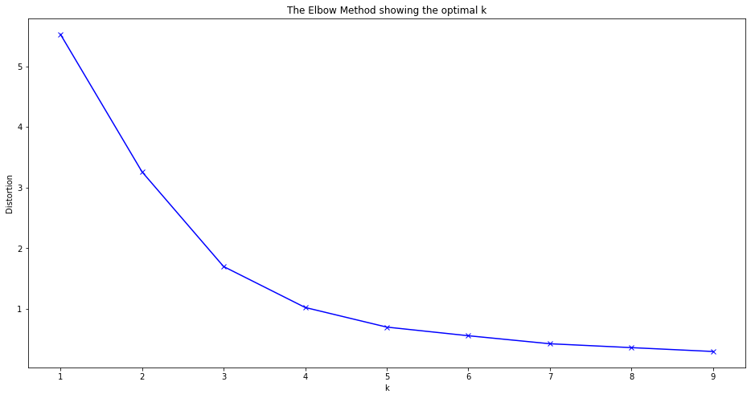

```python
distortions = []
k_values = range(1,10)
for k in k_values:
    kmeanModel = KMeans(n_clusters=k)
    kmeanModel.fit(features)
    distortions.append(kmeanModel.inertia_)

plt.figure(figsize=(16,8))
plt.plot(k_values, distortions, 'bx-')
plt.xlabel('k')
plt.ylabel('Distortion')
plt.title('The Elbow Method showing the optimal k')
plt.show()
```

##### We can see that the elbow point is at `k` = 4. Thus, we can use this value for further processing.

```python
plt.clf()
clusterNum = 4
k_means = KMeans(init = "k-means++", n_clusters = clusterNum, n_init = 12)
k_means.fit(features)
united_df['Cluster'] = k_means.labels_
united_df.head(10)
```

|  | KELURAHAN | Total | Density | Cluster |
| --- | --- | --- | --- | --- |
| 0 | GUBENG | 10 | 15361.0 | 2 |
| 1 | GENTENG | 9 | 8731.0 | 2 |
| 2 | KEDUNGDORO | 8 | 25271.0 | 2 |
| 3 | MANYAR SABRANGAN | 7 | 17892.0 | 2 |
| 4 | KLAMPIS NGASEM | 6 | 18147.0 | 2 |
| 5 | PACAR KELING | 5 | 24144.0 | 0 |
| 6 | AIRLANGGA | 4 | 21193.0 | 0 |
| 7 | KEPUTRAN | 4 | 16610.0 | 0 |
| 8 | MULYOREJO | 4 | 18705.0 | 0 |
| 9 | DUKUH MENANGGAL | 4 | 9156.0 | 0 |

##### We can then group our new `Cluster` column based on the mean of total coffee shops and population density:

```python
united_df.groupby('Cluster').mean()
```

| Cluster | Total | Density |
| --- | --- | --- |
| 0 | 3.571429 | 17180.785714 |
| 1 | 1.194444 | 16305.027778 |
| 2 | 8.000000 | 17080.400000 |
| 3 | 1.222222 | 41145.000000 |

##### We can also count the members belonging to each `Cluster` :

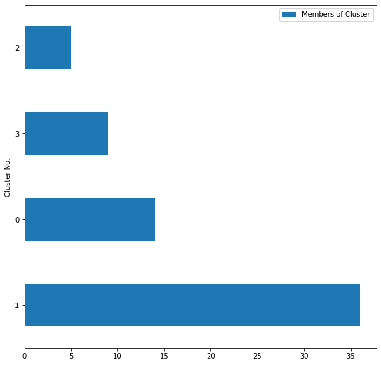

```python
members = united_df['Cluster'].value_counts().rename_axis('Cluster No.').to_frame('Members of Cluster')
members.plot(kind='barh', figsize=(9,9))
```

##### If we want to see which neighborhoods belong to which `Cluster`:

```python
for i in set(united_df['Cluster']):
    neighborhoods_list = united_df[united_df['Cluster'] == i]
    print("For cluster", i)
    print(neighborhoods_list)
    print("---------------------------------------------------")
```

```
For cluster 0
            KELURAHAN  Total  Density  Cluster
5        PACAR KELING      5  24144.0        0
6           AIRLANGGA      4  21193.0        0
7            KEPUTRAN      4  16610.0        0
8           MULYOREJO      4  18705.0        0
9     DUKUH MENANGGAL      4   9156.0        0
10       DUKUH KUPANG      4  16254.0        0
11         DR. SUTOMO      4  17783.0        0
12        PUCANG SEWU      3  15116.0        0
13  NGIDEN JANGKUNGAN      3  16182.0        0
14      RUNGKUT KIDUL      3  14074.0        0
15         BARATAJAYA      3  16996.0        0
16          JAMBANGAN      3  11560.0        0
17          KERTAJAYA      3  26692.0        0
```

[output cut: 61 more lines]

### Finally, we can visualize the clusters:

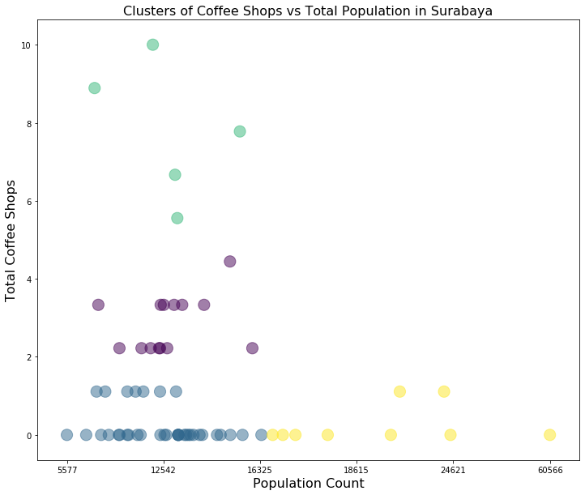

```python
area = (np.pi*(features[:, 1])**2)
x_quartiles = [round(np.percentile(united_df['Density'].values, x)) for x in [(20 * x) for x in range(6)]] # Get an evenly-divided quartiles of six

# Plot the figure
plt.figure(figsize=(12,10))
plt.scatter(features[:, 1], features[:, 0], s = 200, c=k_means.labels_.astype(np.float), alpha=0.5)
plt.xlabel('Population Count', fontsize=16)
plt.xticks(ticks = np.arange(0.0, 1.1, 0.2), labels = x_quartiles)
plt.yticks(ticks = np.arange(0, 1.1, 0.2), labels = np.arange(0, max(united_df.Total.values) + 1, 2))
plt.ylabel('Total Coffee Shops', fontsize=16)
plt.title("Clusters of Coffee Shops vs Total Population in Surabaya", fontsize=16)
plt.show()
```

# Conclusion

Looking through our scatter plot visualization and the density and total coffee shops for each cluster, we can draw a conclusion and label each of our clusters:

1. **Cluster 3** has the second-to-least members, a few coffee shops, with the most densely-populated neighborhoods. We can say that this is indeed the **most prospective cluster**.
2. **Cluster 0** has a moderate amount of members, with each having a relatively high number of total coffee shops. We can say that this area is the **mid-highly prospective cluster**.
3. **Cluster 1** has the most members, alongside a few coffee shops in each. With the lower half of population density belonging to this cluster, this area is the **moderately prospective cluster**.
4. **Cluster 2** has the fewest members, but also the most amount of total coffee shops. This area is the **least prospective cluster**.

We can then change the cluster numerical values into our verdict, in our `united_df` dataframe.

```python
united_df.Cluster.replace({3:'High', 0:'Mid-high', 1:'Moderate', 2:'Least'}, inplace=True)
united_df.head()
```

|  | KELURAHAN | Total | Density | Cluster |
| --- | --- | --- | --- | --- |
| 0 | GUBENG | 10 | 15361.0 | Least |
| 1 | GENTENG | 9 | 8731.0 | Least |
| 2 | KEDUNGDORO | 8 | 25271.0 | Least |
| 3 | MANYAR SABRANGAN | 7 | 17892.0 | Least |
| 4 | KLAMPIS NGASEM | 6 | 18147.0 | Least |

## Most prospective areas:

Displaying the top 5 areas for this cluster.

```python
united_df[united_df['Cluster'] == 'High'].head()
```

|  | KELURAHAN | Total | Density | Cluster |
| --- | --- | --- | --- | --- |
| 19 | MOJO | 2 | 48516.0 | High |
| 25 | WONOKROMO | 2 | 43480.0 | High |
| 35 | TANAH KALI KEDINDING | 1 | 60566.0 | High |
| 40 | SAWUNGGALING | 1 | 29006.0 | High |
| 42 | PUTAT JAYA | 1 | 49249.0 | High |

## Moderate-to-high prospective areas:

Displaying the top 5 areas for this cluster.

```python
united_df[united_df['Cluster'] == 'Mid-high'].head()
```

|  | KELURAHAN | Total | Density | Cluster |
| --- | --- | --- | --- | --- |
| 5 | PACAR KELING | 5 | 24144.0 | Mid-high |
| 6 | AIRLANGGA | 4 | 21193.0 | Mid-high |
| 7 | KEPUTRAN | 4 | 16610.0 | Mid-high |
| 8 | MULYOREJO | 4 | 18705.0 | Mid-high |
| 9 | DUKUH MENANGGAL | 4 | 9156.0 | Mid-high |

## Moderately prospective areas:

Displaying the top 5 areas for this cluster.

```python
united_df[united_df['Cluster'] == 'Moderate'].head()
```

|  | KELURAHAN | Total | Density | Cluster |
| --- | --- | --- | --- | --- |
| 20 | GREGES | 2 | 12455.0 | Moderate |
| 21 | JERUK | 2 | 8956.0 | Moderate |
| 22 | KALIJUDAN | 2 | 14282.0 | Moderate |
| 23 | MENANGGAL | 2 | 9945.0 | Moderate |
| 24 | EMBONG KALIASIN | 2 | 13397.0 | Moderate |

## Least prospective areas:

Displaying the top 5 areas for this cluster.

```python
united_df[united_df['Cluster'] == 'Least'].head()
```

|  | KELURAHAN | Total | Density | Cluster |
| --- | --- | --- | --- | --- |
| 0 | GUBENG | 10 | 15361.0 | Least |
| 1 | GENTENG | 9 | 8731.0 | Least |
| 2 | KEDUNGDORO | 8 | 25271.0 | Least |
| 3 | MANYAR SABRANGAN | 7 | 17892.0 | Least |
| 4 | KLAMPIS NGASEM | 6 | 18147.0 | Least |

*Written, tested, and published by Charis Chrisna* [(portfolio)](http://notpestilence.github.io).